# w4_project

S. Marceau

12/03/2020

# Summary

This project aims at predicting the manner how Six young health participants perform barbell lifts correctly and incorrectly in 5 different ways (Class A, B, C, D, E, A being the right way). To do so, their activity was recorded using devices such as Jawbone Up, Nike FuelBand, and Fitbit to collect a large amount of data from accelerometers on the belt, forearm, arm, and dumbell about personal activity.

After loading the relevant data from csv files, we will review the class distribution to carry out a data cross validation by splitting the training set into a train and test set. We will explore the data set and select the features to be used as predictors. Then will will carry out a dimension reduction using Principal Component and check for class separation. Finally we will fit several classification models to best predict the one activity class.

# Data loading

```r
library(caret)
library(dplyr)

training<-read.csv("sources/pml-training.csv",na.strings=c("","NA"))
testing<-read.csv("sources/pml-testing.csv",na.strings=c("","NA"))
```

# Data cross validation

## class distribution

from the chart below we notice that classes are not equally balanced. In particular classe A is much more frequent dans other classes.

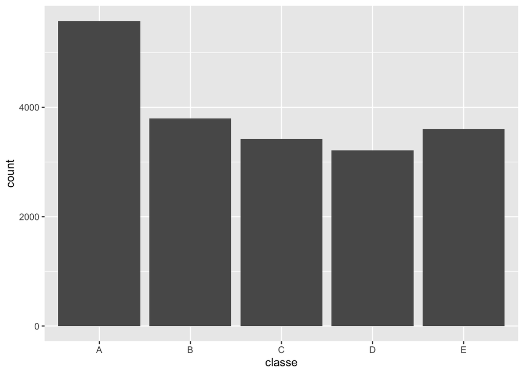

training set rows: 19622 as training set contains many observations will will split the training set into a train set and a test set, keeping the testing set as a validation one.

```r
# validation set
trainIn<-createDataPartition(y=training$classe,p = 0.75,list = TRUE)[[1]]
trainData<-training[trainIn,]
testData<-training[-trainIn,]
```

# EDA

## data analysis

```r
library(ggplot2)

# get col with NAs
naCount<-as.vector(apply(trainData,2,function(x)sum(is.na(x))))
# names(trainData[,naCount>0])
# review NA col
# summary(trainData[,naCount==0])

# build response / predictor
xTrain<-trainData[,naCount==0]
xTrain<-xTrain[,-2]
# remove unncessary columns
xTrain<-xTrain[,-which(names(xTrain) %in% c("X","classe","cvtd_timestamp","new_window","num_window","raw_timestamp_part_1","raw_timestamp_part_2"))]
yTrain<-factor(trainData[,160])
testData$classe<-as.factor(testData$classe)
```

## correlation review

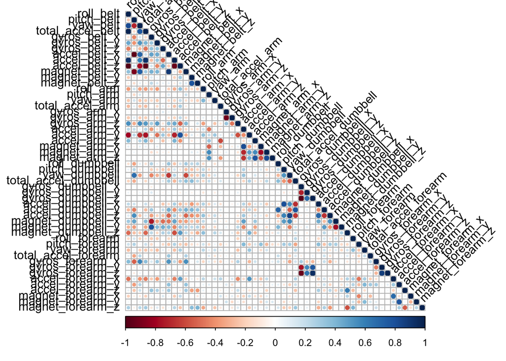

```r
library(corrplot)
predCor<-cor(xTrain)
corrplot(predCor,method="circle",type="lower",tl.col="black", tl.srt=45,sig.level = 0.5)
```

```r
# keep only predictors with less than 0.8 correlation
highCorr <- findCorrelation(predCor, cutoff = .8)
xTrain<-xTrain[,-highCorr]
df<-mutate(xTrain,y=yTrain)
```

## Filtering predictors

```r
# nearZero var
zeroVar<-nearZeroVar(scale(xTrain))
# measuring predictor importance
predictorRoc<-filterVarImp(x=xTrain,y=yTrain, nonpara = TRUE)
# head(predictorRoc)
```

Near Zero var nb: 0

# PCA

## checking for best number of Principal Component

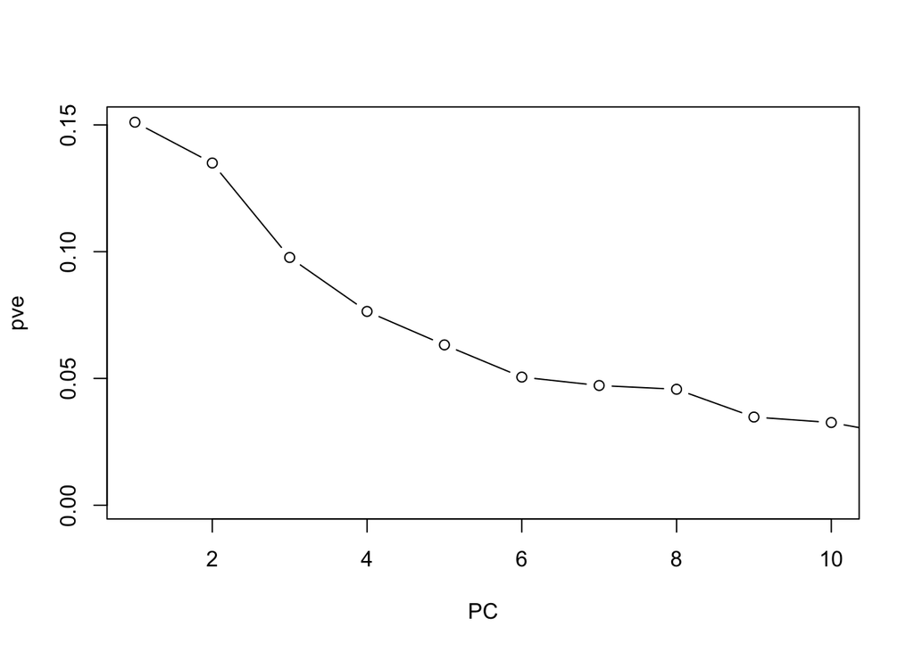

as per chart above and looking at the elbow, we will keep the fourth principal components

## Vizualisation Principal Component correlations

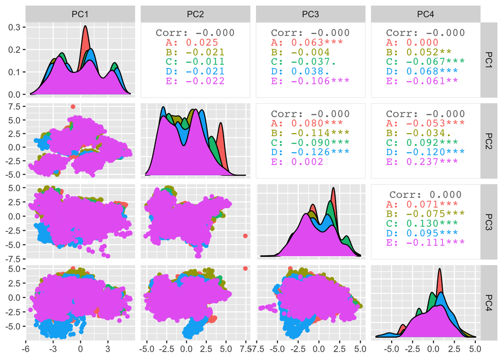

# Fit Models

## Kmeans

```r
km.fit<-kmeans(xTrain,5,nstart=50)
# km.fit$tot.withinss
knn.mat<-confusionMatrix(factor(km.fit$cluster, labels = c("A", "B", "C", "D", "E")),yTrain)
```

## qda

```r
library(MASS)
# qda.fit<-qda(y~.,data = df)
qda.fit<-train(y~.,data=df, method="qda")
qda.pred<-predict(qda.fit,newdata = testData)
qda.mat<-confusionMatrix(qda.pred,testData$classe)
```

## Naive Bayes

```r
library(e1071)
bayes.fit<-naiveBayes(y~., data = df, laplace = 2)
bayes.pred<-predict(bayes.fit,newdata = testData, type = "class")
bayes.mat<-confusionMatrix(bayes.pred,testData$classe)
```

## SVM

```r
library(e1071)
svm.fit<-svm(y~.,data=df,kernel="radial", cross=10)
svm.mat<-confusionMatrix(svm.fit$fitted,yTrain)

# library(caret)
# ctrl <- trainControl(method = "cv", index = trainIn)
# fitControl <- trainControl(method="repeatedcv",
#                            number=10,
#                            repeats=3,
#                            summaryFunction = multiClassSummary,
#                            classProbs = TRUE)
#
# svm.fit<-train(y ~ ., data = df,
#                  method = "svmRadial",
#                  trControl = fitControl,
#                  preProc = c("center", "scale"))
# svm.pred<-predict(svm.fit,newdata = testData)
# svm.mat<-confusionMatrix(svm.pred,testData$classe)
# plot(svm.fit,df.pca)
```

## Boosting

```r
# boost.fit <- train(y ~ ., data = df,
#                    method="gbm",
#                    trControl=fitControl,
#                    verbose=FALSE)

library(C50)
boost.fit<-C5.0(y~.,data=df, trials=10)
boost.pred<-predict(boost.fit,newdata = testData)
boost.mat<-confusionMatrix(boost.pred,testData$classe)
```

## Random forest

```r
library(randomForest)
set.seed(791)
rf.fit <- randomForest(y ~ ., data = df,nTree=2000,importance=TRUE)
# rf.fit<-train(y~., data=df,
#               method="rf",
#               ntree=1000)

rf.pred<-predict(rf.fit,newdata = testData, type="class")
rf.mat<-confusionMatrix(rf.pred,testData$classe)
```

# Comparing models and selecting final predictive model

Looking at model accuracies, Random forest has the highest accuracy (above 99%) with a 98.7% kappa. We then keep the Random Forest as our predicting model for training activity.

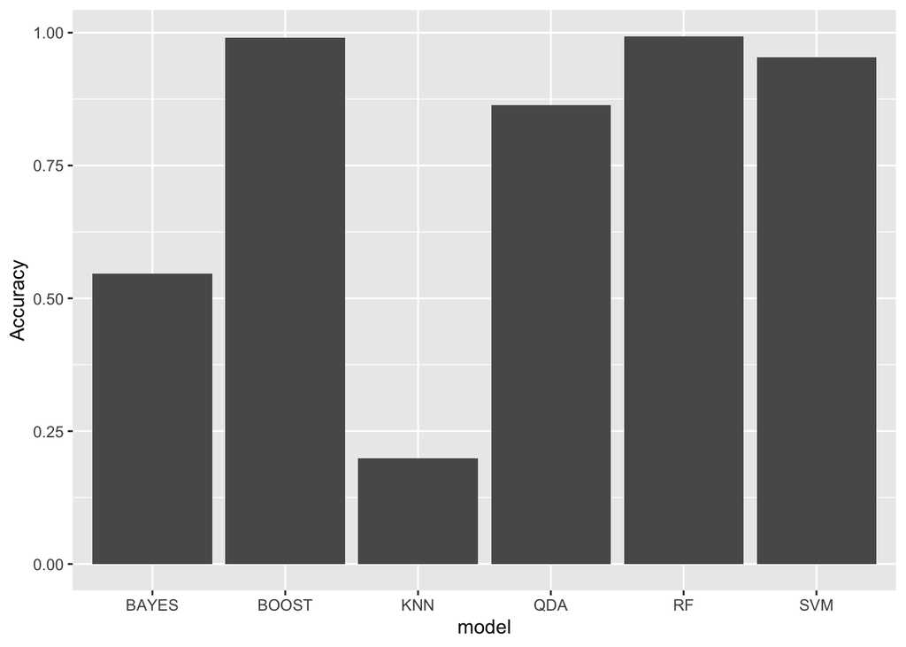